# Homework #1: Supervised Learning

Chloe Fauvel

Due: Wed Feb 24 | 10:55am

**SYS 4582/6018 | Spring 2021 | University of Virginia**

# Required R packages and Directories

```r
data.dir = 'https://mdporter.github.io/SYS6018/data/' # data directory
library(R6018)     # functions for SYS-6018
library(tidyverse) # functions for data manipulation
library(boot)
library(broom)
library(splines)
library(FNN)
library(dplyr)
```

# Problem 1: Bootstrapping

Bootstrap resampling can be used to quantify the uncertainty in a fitted curve.

## a. Create a set of functions to generate data from the following distributions:

$$\begin{align*}
X &\sim \mathcal{U}(0, 2) \qquad \text{Uniform in $[0,2]$}\\
Y &= 1 + 2x + 5\sin(5x) + \epsilon \\
\epsilon &\sim \mathcal{N}(0,\, \sigma=2.5)
\end{align*}$$

```r
sim_x <- function(n) runif(n, min=0, max=2)

f <- function(x) {
  1 + 2*x + 5*sin(5*x)
}

sim_y <- function(x) {
  n = length(x)
  f(x) + rnorm(n, mean=0, sd=2.5)
}
```

## b. Simulate $n=100$ realizations from these distributions. Produce a scatterplot and draw the true regression line $f(x) = E[Y \mid X=x]$. Use `set.seed(211)` prior to generating the data.

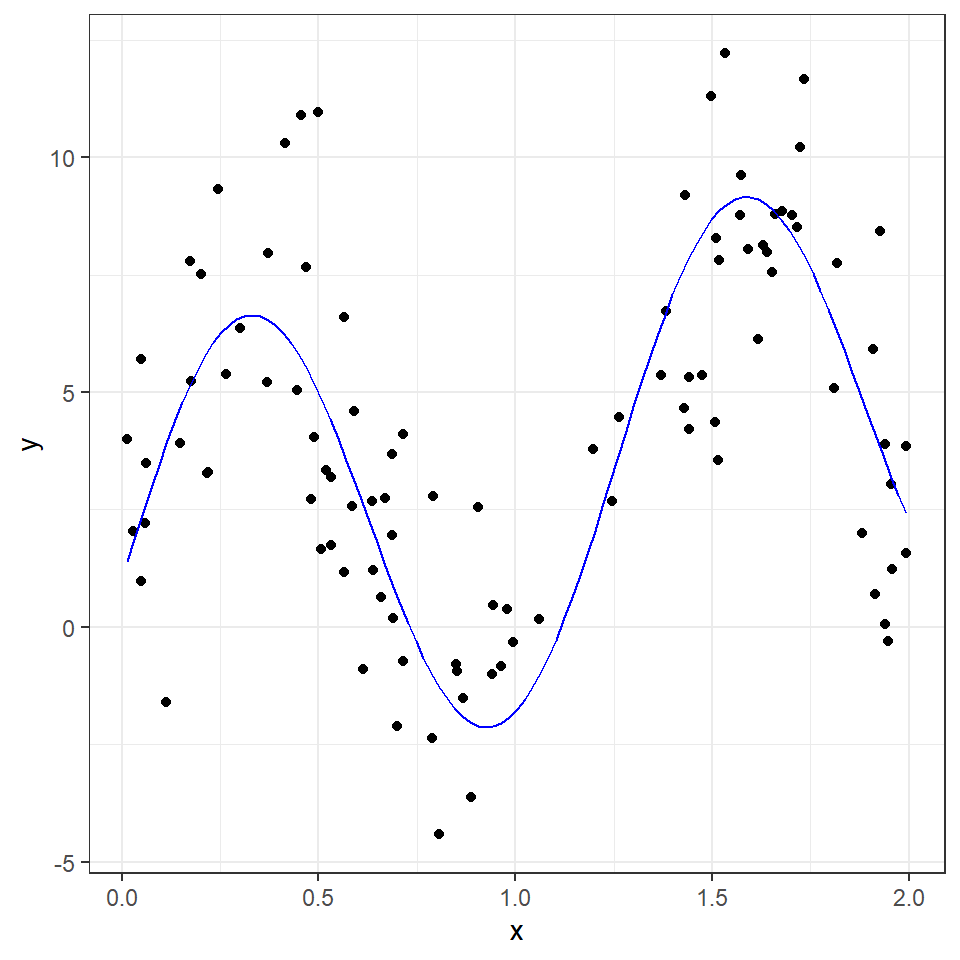

```r
n <- 100
set.seed(211)

x <- sim_x(n)
y <- sim_y(x)
data_train <- tibble(x,y)

scatter <- ggplot(data_train, aes(x=x, y=y)) + geom_point()

scatter + geom_function(fun=f, color="blue")
```

## c. Fit a 5th degree polynomial. Produce a scatterplot and draw the *estimated* regression curve.

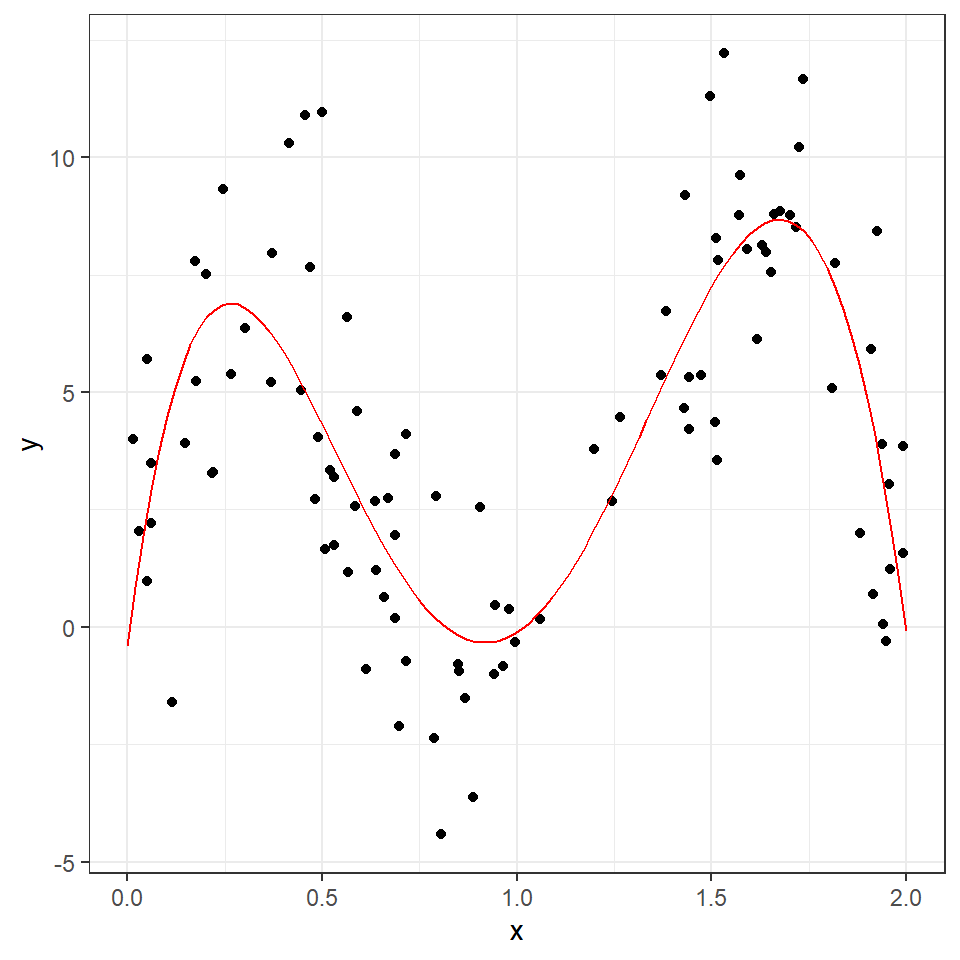

```r
model <- lm(y~poly(x,degree=5), data=data_train)
xseq <- seq(0,2, length=100)
yhat <- predict(model, newdata=tibble(x=xseq))

scatter +
  geom_line(data=tibble(x=xseq, y=yhat), color='red')
```

## d. Draw 200 bootstrap samples, fit a 5th degree polynomial to each bootstrap sample, and make predictions at `eval.pts = seq(0, 2, length=100)`

- Set the seed (use `set.seed(212)`) so your results are reproducible.
- Produce a scatterplot and add the 200 bootstrap curves

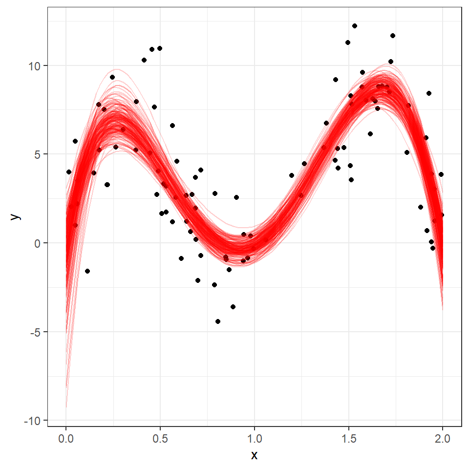

```r
n <- 100  #100 training observations
M <- 200  #200 bootstrap samples
beta <- data.frame(matrix(nrow=M,ncol=100))
eval.pts = seq(0, 2, length=100)
plot <- scatter

set.seed(212)

for(m in 1:M){
  ind <- sample(n, replace=TRUE)
  data.boot <- data_train[ind,]
  m.boot <- lm(y~poly(x,degree=5), data=data.boot)

  pred <- predict(m.boot, newdata=tibble(x=eval.pts))
  beta[m,] <- pred
  plot <- plot + geom_line(data=tibble(x=eval.pts,y=pred), color='red', alpha=0.2)
}

plot
```

## e. Calculate the pointwise 95% confidence intervals from the bootstrap samples. That is, for each $x \in {\rm eval.pts}$, calculate the upper and lower limits such that only 5% of the curves fall outside the interval at $x$.

- Remake the plot from part *c*, but add the upper and lower boundaries from the 95% confidence intervals.

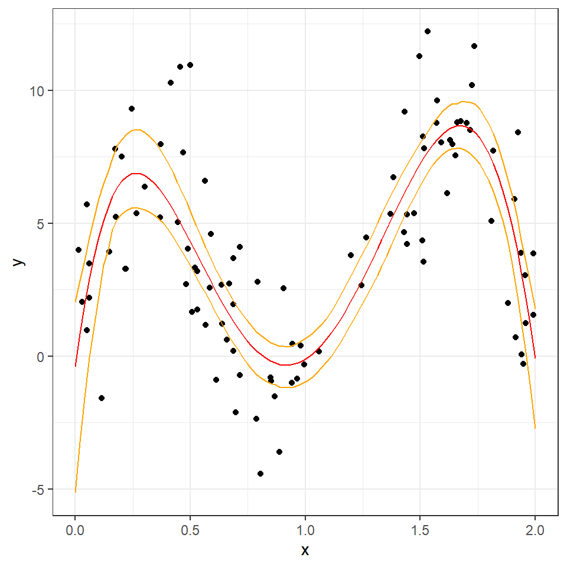

```r
CI <- data.frame(matrix(nrow=100,ncol=2))
names(CI) <- c("lower_limit", "upper_limit")
for (i in 1:100) {
  CI[i,] <- quantile(beta[,i], probs=c(0.025,0.975))
}

scatter +
  geom_line(data=tibble(x=xseq, y=yhat), color='red') +
  geom_line(data=tibble(x=eval.pts, y=CI$lower_limit), color='orange') +
  geom_line(data=tibble(x=eval.pts, y=CI$upper_limit), color='orange')
```

# Problem 2: V-Fold cross-validation with $k$ nearest neighbors

Run 10-fold cross-validation on the data generated in part 1b to select the optimal $k$ in a k-nearest neighbor (kNN) model. Then evaluate how well cross-validation performed by evaluating the performance on a large test set. The steps below will guide you.

## a. Use $10$-fold cross-validation to find the value of $k$ (i.e., neighborhood size) that provides the smallest cross-validated MSE using a kNN model.

- Search over $k=3,4,\ldots, 50$.
- Use `set.seed(221)` prior to generating the folds to ensure the results are replicable.
- Show the following:
  - the optimal $k$ (as determined by cross-validation)
  - the corresponding estimated MSE
  - produce a plot with $k$ on the x-axis and the estimated MSE on the y-axis (optional: add 1-standard error bars).
- Notation: *v*-fold cross-validation; *k*-nearest neighbor. Don’t get yourself confused.

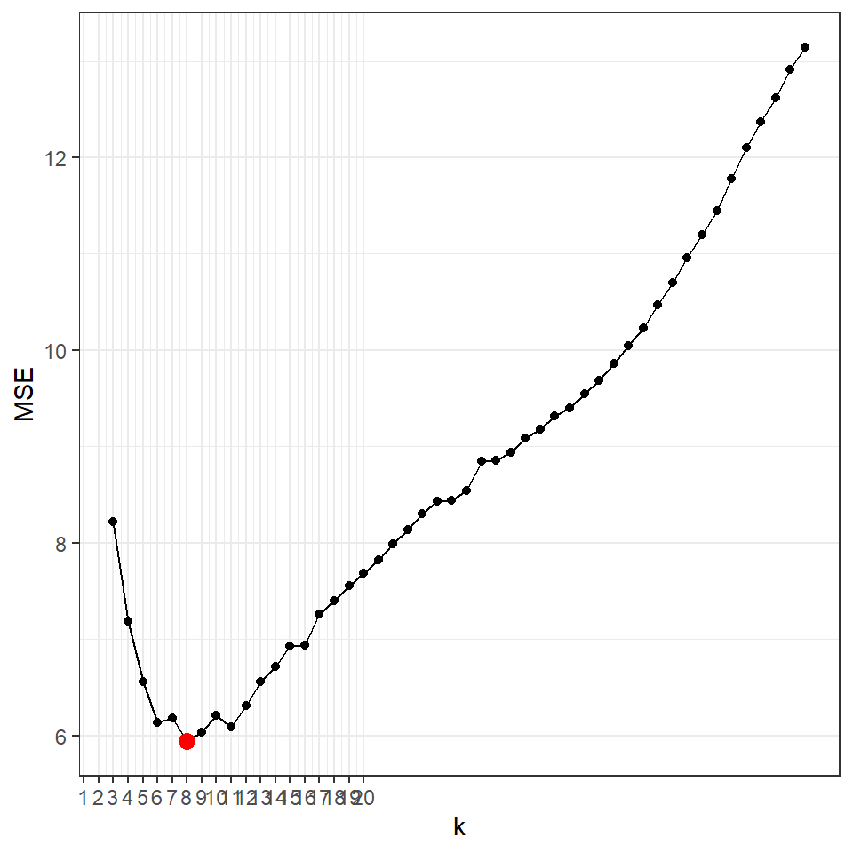

```r
set.seed(221)

# function for fitting knn models with k=3-50 and calculating MSE
knn_fit <- function(training, testing, K=seq(3, 50, by=1)) {
  MSE = numeric(length(K))
  for(i in 1:length(K)) {
    #- set tuning parameter value
    k = K[i]
    #- fit with training data
    fit <- knn.reg(train=training[,'x',drop=FALSE],
                   y=training$y,
                   test=testing[,'x',drop=FALSE],
                   k=k)
    #- get errors / loss
    MSE[i] = mean((testing$y - fit$pred)^2)
  }
  tibble(k=K, mse=MSE)
}

n.folds <- 10
fold <- sample(rep(1:n.folds, length=n))
K <- seq(3, 50, by=1)
results <- tibble()

# 10-fold cross-validation
for(j in 1:n.folds){
  val <- which(fold == j) # indices of validation data
  train <- which(fold != j) # indices of training data
  n.val <- length(val) # number of observations in validation

  #-- fit set of kNN models
  results_j <- knn_fit(data_train[train,], data_train[val,], K=K)
  results <- bind_rows(results,
                      results_j %>% mutate(n.val, fold=j, edf=90/k))
}

R <- results %>%
  mutate(sse = mse*n.val) %>%
  group_by(k) %>%
  summarize(K=n(), edf=mean(edf), sse = sum(sse), MSE=sse/nrow(data_train),
            mse_mu = mean(mse), mse_sd = sd(mse), se = mse_sd/sqrt(K))

R %>%
  ggplot(aes(k, MSE)) + geom_point() + geom_line() +
  geom_point(data=. %>% filter(MSE==min(MSE)), color="red", size=3) +
  scale_x_continuous(breaks=1:20)
```

```r
tibble(R[which(R$MSE==min(R$MSE)),])
```

| k | K | edf | sse | MSE | mse_mu | mse_sd | se |
| --- | --- | --- | --- | --- | --- | --- | --- |
| 8 | 10 | 11.25 | 593.7 | 5.937 | 5.937 | 1.885 | 0.5962 |

## b. The $k$ (number of neighbors) in a kNN model determines the effective degrees of freedom *edf*. What is the optimal *edf*? Be sure to use the correct sample size when making this calculation. Produce a plot similar to that from part *a*, but use *edf* (effective degrees of freedom) on the x-axis.

The optimal edf is whichever k (number of neighbors) produced the lowest MSE. Since k=8 produced the lowest MSE, the optimal effective degrees of freedom $= n/k = 90/8 = 11.25$

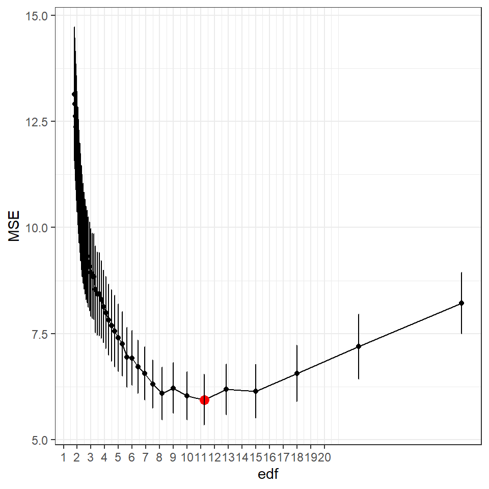

```r
R %>%
  ggplot(aes(x=edf, y=MSE)) + geom_point() + geom_line() +
  geom_point(data=. %>% filter(MSE==min(MSE)), color="red", size=3) +
  geom_errorbar(aes(ymin=MSE-se, ymax=MSE+se)) +
  scale_x_continuous(breaks=1:20)
```

## c. After running cross-validation, a final model fit from *all* of the training data needs to be produced to make predictions. What value of $k$ would you choose? Why?

Based on the 10-fold cross-validation method we have just applied, I would choose k=8 to train my model since it produced the lowest cross-validation MSE.

## d. Now we will see how well cross-validation performed. Simulate a test data set of $50000$ observations from the same distributions. Use `set.seed(223)` prior to generating the test data.

- Fit a set of kNN models, using the full training data, and calculate the mean squared error (MSE) on the test data for each model. Use the same $k$ values in *a*.
- Report the optimal $k$, the corresponding *edf*, and MSE based on the test set.

```r
set.seed(223)
n.test <- 50000
x.test <- sim_x(n.test)
y.test <- sim_y(x.test)
data_test <- tibble(x=x.test,y=y.test)
K <- seq(3, 50, by=1)
MSE <- numeric(length(K))

for (i in 1:length(K)) {
  fit <- knn.reg(train=data_train[,'x'],
               y=data_train$y,
               test=data_test[,'x'],
               k=K[i])
  MSE[i] = mean((data_test$y - fit$pred)^2)
}

MSE.test <- tibble(k=K, mse=MSE, edf=90/K)
tibble(MSE.test[which(MSE.test$mse == min(MSE.test$mse)),])
```

| k | mse | edf |
| --- | --- | --- |
| 13 | 7.109 | 6.923 |

## e. Plot both the cross-validation estimated and (true) error calculated from the test data on the same plot. See Figure 5.6 in ISL (pg 182) as a guide.

- Produce two plots: one with $k$ on the x-axis and one with *edf* on the x-axis.
- Each plot should have two lines: one from part *a* and one from part *d*

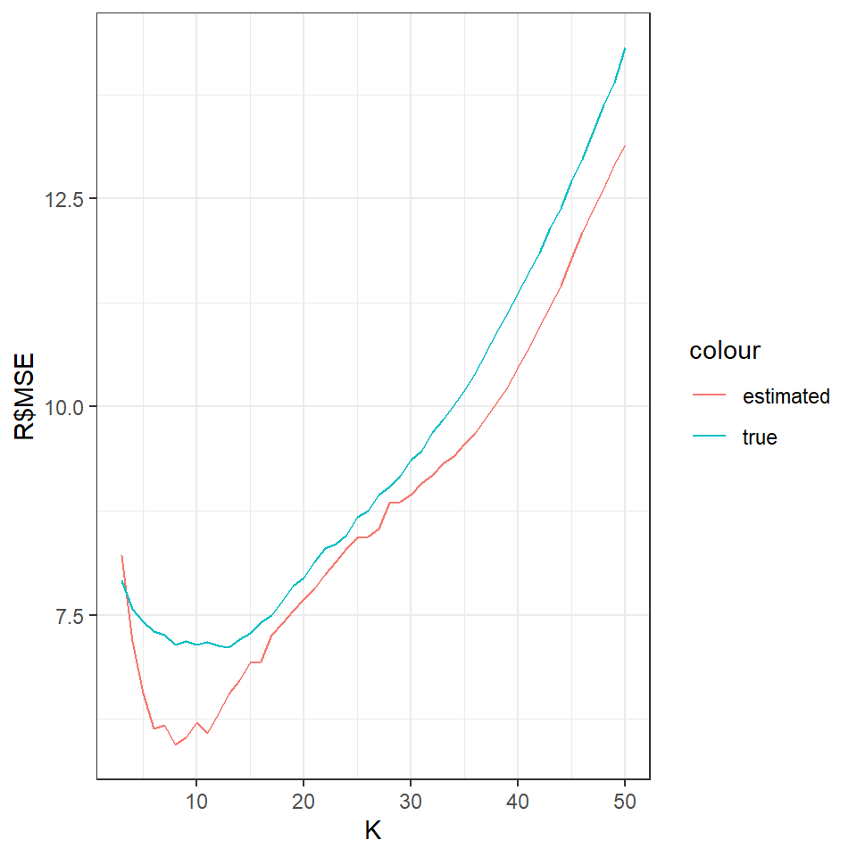

```r
ggplot() +
  geom_line(aes(x=K, y=R$MSE, color='estimated')) +
  geom_line(aes(x=K, y=MSE.test$mse, color='true'))
```

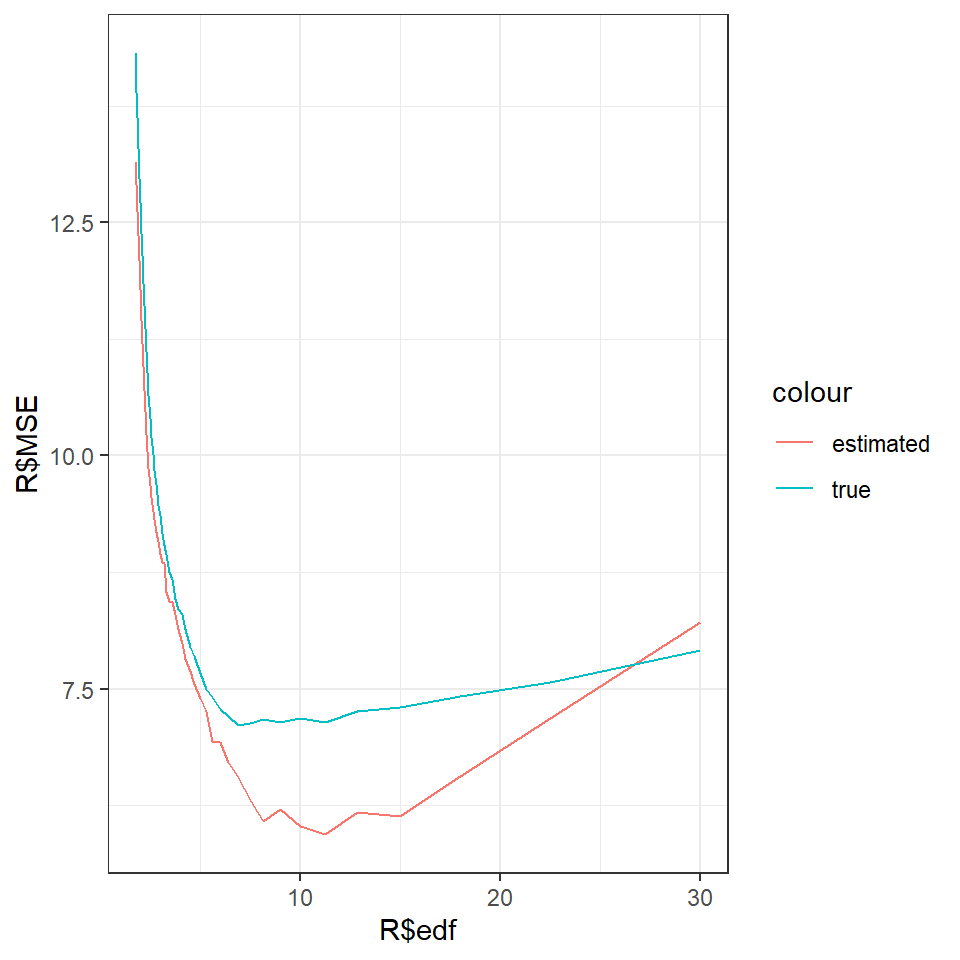

```r
ggplot() +
  geom_line(aes(x=R$edf, y=R$MSE, color='estimated')) +
  geom_line(aes(x=MSE.test$edf, y=MSE.test$mse, color='true'))
```

## f. Based on the plots from *e*, does it appear that cross-validation worked as intended? How sensitive is the choice of $k$ on the resulting test MSE?

No, it does not seem that cross-validation worked as intended in finding the best k number of neighbors that would produce the lowest MSE.

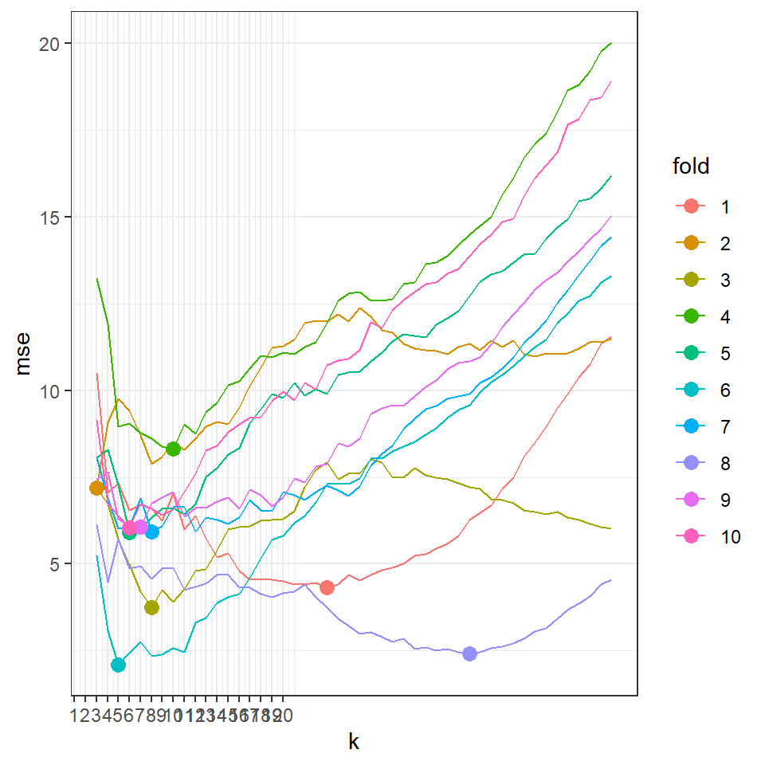

```r
results %>%
ggplot(aes(k, mse, color=factor(fold))) + geom_line() +
geom_point(data=. %>% group_by(fold) %>% filter(mse==min(mse)), size=3) +
labs(color="fold") +
scale_x_continuous(breaks=1:20)
```

Based on the graph above, we can say that there is a lot of variability, and therefore sensitivity, between the choice of k and the resulting MSE.